# Lab 7: Functions + Fish

Author

Alex Lung

Published

November 10, 2024

The goal of this lab is learn more about exploring missing data and writing modular code.

```r
library(tidyverse)
library(here)

fish <- read.csv(here("data", "BlackfootFish.csv"))
```

## 1 The Data

This lab’s data concerns mark-recapture data on four species of trout from the Blackfoot River outside of Helena, Montana. These four species are **rainbow trout (RBT)**, **westslope cutthroat trout (WCT)**, **bull trout**, and **brown trout**.

Mark-recapture is a common method used by ecologists to estimate a population’s size when it is impossible to conduct a census (count every animal). This method works by *tagging* animals with a tracking device so that scientists can track their movement and presence.

## 2 Data Exploration

The measurements of each captured fish were taken by a biologist on a raft in the river. The lack of a laboratory setting opens the door to the possibility of measurement errors.

**1. Let’s look for missing values in the dataset. Output ONE table that answers BOTH of the following questions:**

- **How many observations have missing values?**
- **What variable(s) have missing values present?**

**You should use `across()`!**

```r
fish |>
  summarise(
    # Count missing values in each column
    across(everything(), ~ sum(is.na(.)))) |>

    pivot_longer(everything(),
                 names_to = "Variable",
                 values_to = "Missing_Values") |>

  # Determine the columns that have missing values.
    filter(Missing_Values > 0)
```

```
# A tibble: 1 × 2
  Variable Missing_Values
  <chr>             <int>
1 weight             1796
```

**2. Create ONE thoughtful visualization that explores the frequency of missing values across the different years, sections, and trips.**

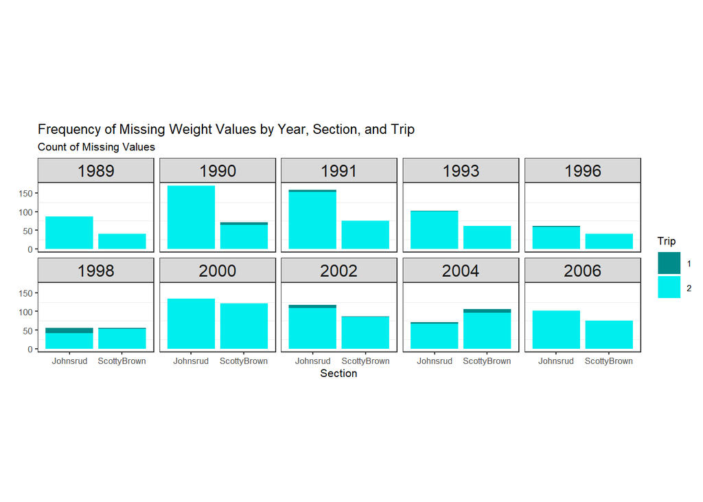

```r
fish |>

  #Make sure it is rows lacking wight data
  filter(is.na(weight)) |>

  #Alter into a usable distincter variable
  mutate(trip = as.factor(trip)) |>

  group_by(year, section, trip) |>

  summarise(Missing_Count = n(), .groups = "drop") |>


  ggplot(aes(x = section, y = Missing_Count, fill = trip)) +

  geom_bar(stat = "identity") +

  facet_wrap(~ year, ncol = 5) +

  labs(
    title = "Frequency of Missing Weight Values by Year, Section, and Trip",
    subtitle = "Count of Missing Values",
    x = "Section",
    y = "",
    fill = "Trip"
  ) +

  theme_bw(base_size = 8) +

  theme(
    strip.text = element_text(size = 12),
    aspect.ratio = 0.6,
    panel.grid.major = element_blank()
  ) +

  scale_fill_manual(values = c("darkcyan", "cyan2"))
```

## 3 Rescaling the Data

If I wanted to rescale every quantitative variable in my dataset so that they only have values between 0 and 1, I could use this formula:

$$y_{scaled} = \frac{y_i - min\{y_1, y_2,..., y_n\}}{max\{y_1, y_2,..., y_n\}
- min\{y_1, y_2,..., y_n\}}$$

I might write the following `R` code to carry out the rescaling procedure for the `length` and `weight` columns of the `BlackfoorFish` data:

```r
fish <- fish |>
  mutate(length = (length - min(length, na.rm = TRUE)) /
           (max(length, na.rm = TRUE) - min(length, na.rm = TRUE)),
         weight = (weight - min(weight, na.rm = TRUE)) /
           (max(weight, na.rm = TRUE) - min(length, na.rm = TRUE)))
```

This process of duplicating an action multiple times can make it difficult to understand the intent of the process. *Additionally, it can make it very difficult to spot mistakes.*

**3. What is the mistake I made in the above rescaling code?**

*This mistake in the code chunk above is for the mutating of the weight variable, where the subtracting of the denominator has the function “min(length, na.rm = TRUE)”, which should be “min(weight, na.rm = TRUE)” as we are scaling for weight.*

When you find yourself copy-pasting lines of code, it’s time to write a function, instead!

**4. Transform the repeated process above into a `rescale_01()` function. Your function should…**

- **… take a single vector as input.**
- **… return the rescaled vector.**

```r
rescale_01 <- function(x) {

  case_when(!is.numeric(x) ~ "Error: Input must be a numeric vector.",
            length(x) <= 1 ~ "Error: Input must have at least two elements."
            )

  x = (x - min(x, na.rm = TRUE)) / (max(x, na.rm = TRUE) - min(x, na.rm = TRUE))
  return(x)
}
```

**Reflection: As we are focusing on getting the process to be more efficient along with how we code, it was best to forgo the use of multiple if statements in favor of a single function that would preform the very same actions. When looking at my code, it is best to look deeper and determine if what I created could be compressed down to a form that is both more readable and would end up making the processing of R quicker.**

**Efficiency**

Think about the efficiency of the function you wrote. Are you calling the **same** function multiple times? You might want to look into the `range()` function.

**5. Let’s incorporate some input validation into your function. Modify your previous code so that the function stops if …**

- **… the input vector is not numeric.**
- **… the length of the input vector is not greater than 1.**

**Modify Previous Code**

Do not create a new code chunk here – simply add these stops to your function above!

## 4 Test Your Function

**6. Run the code below to test your function. Verify that the maximum of your rescaled vector is 1 and the minimum is 0!**

```r
x <- c(1:25, NA)

rescaled <- rescale_01(x)
min(rescaled, na.rm = TRUE)
```

```
[1] 0
```

```r
max(rescaled, na.rm = TRUE)
```

```
[1] 1
```

Next, let’s test the function on the `length` column of the `BlackfootFish` data.

**7. The code below makes a histogram of the original values of `length`. Add a plot of the rescaled values of `length`. Output your plots side-by-side, so the reader can confirm the only aspect that has changed is the scale.**

**Warning**

This will require you to call your `rescale_01()` function within a `mutate()` statement in order to create a `length_scaled` variable.

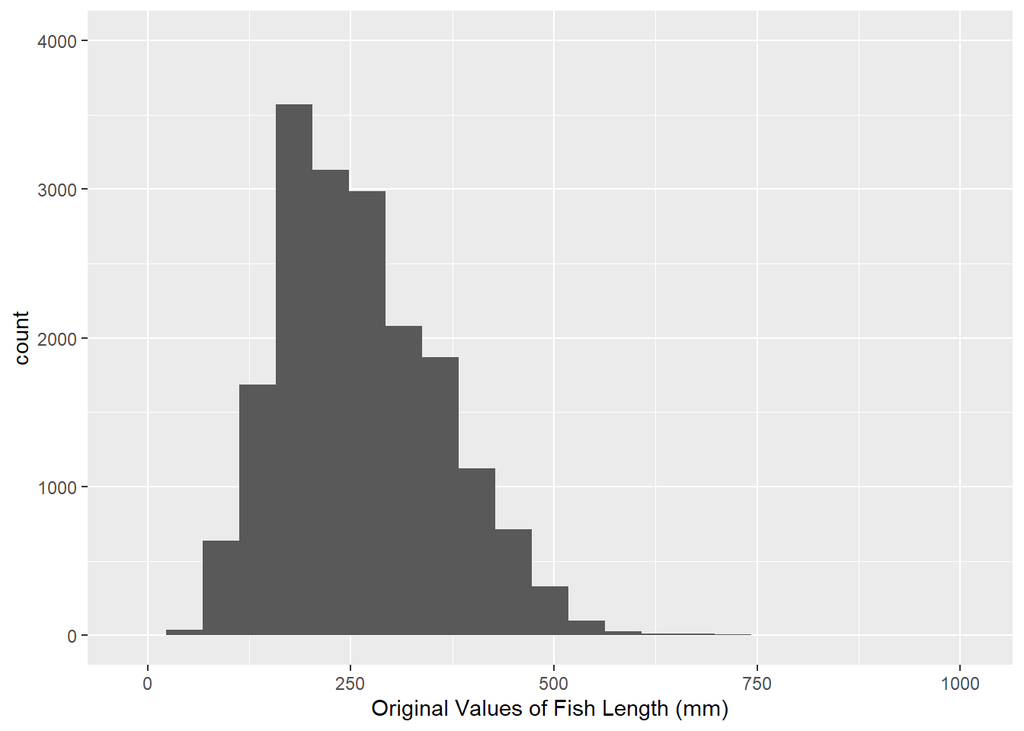

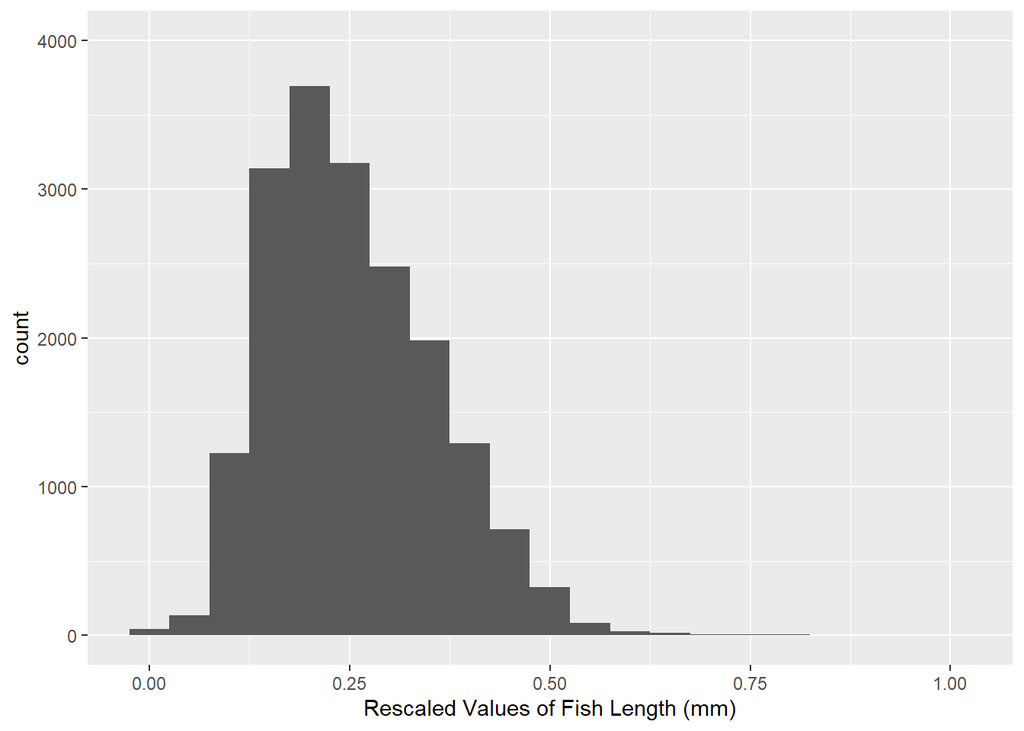

```r
fish |>
  ggplot(aes(x = length)) +
  geom_histogram(binwidth = 45) +
  labs(x = "Original Values of Fish Length (mm)") +
  scale_y_continuous(limits = c(0,4000))
# Code for Q7 plot.

fish |>
  mutate(length_scaled = rescale_01(length)) |>
  ggplot(aes(x = length_scaled)) +

  #Binwidth had to be altered to adjust for the value that are between 0 and 1.
  geom_histogram(binwidth = 0.05) +
  labs(x = "Rescaled Values of Fish Length (mm)") +
  scale_y_continuous(limits = c(0,4000))
```

**Tip**

1. Set the y-axis limits for both plots to go from 0 to 4000 to allow for direct comparison across plots.
2. Pay attention to `binwidth`!
3. Use a Quarto code chunk option to put the plots side-by-side.

## 5 Use Variables within a Dataset

Suppose you would like for your `rescale()` function to perform operations on a **variable within a dataset**. Ideally, your function would take in a data frame and a variable name as inputs and return a data frame where the variable has been rescaled.

**8. Create a `rescale_column()` function that accepts two arguments:**

- **a dataframe**
- **the name(s) of the variable(s) to be rescaled**

**The body of the function should call the original `rescale_01()` function you wrote previously. Your solution MUST use one of the `rlang` options from class.**

**Tip**

If you are struggling with this task, I recommend looking back over the [data frame functions](https://r4ds.hadley.nz/functions.html#data-frame-functions) section of R for Data Science!

```r
rescale_column <- function(df, columns) {

  #Added to check if the df is really a dataframe
  stopifnot(is.data.frame(df))

  df <- df |>
    mutate(across({{columns}}, rescale_01))

  return(df)
}
```

**9. Use your `rescale_column()` function to rescale *both* the `length` and `weight` columns.**

**Warning**

I expect that you carry out this process by calling the `rescale_column()` function only ONE time!

```r
rescale_column(fish, c(length, weight))
```

[output not shown]

[output cut: 14272 more lines]